# Майнор "Интеллектуальный анализ данных"

# Курс "Введение в анализ данных"

# Лабораторная работа №1. Обработка и первичный анализ данных

## Данные

В рамках данной лабораторной работы вам предлагается проанализировать набор данных о студентах двух школ в Португалии.  
В файле `students_data.csv` представлена информация о студентах, посещающих два курса - математику (`Math`) и поргутальский язык (`Por`). Некоторые студенты представлены в обоих курсах, некоторые - только в одном. Для каждого студента известны три оценки по курсу: оценка за первое полугодие (`G1`), оценка за второе полугодие (`G2`) и итоговая оценка за год (`G3`).

```python
import pandas as pd
import matplotlib.pyplot as plt
import seaborn as sns
```

```python
pd.set_option('display.max_columns', None)
pd.set_option('display.max_colwidth', None)
```

```python
data = pd.read_csv("students_data.csv")
data.shape
```

```
(1044, 36)
```

```python
data.head(15)
```

|  | ID | Subject | school | sex | age | address | famsize | Pstatus | Medu | Fedu | Mjob | Fjob | reason | guardian | traveltime | studytime | failures | schoolsup | famsup | paid | activities | nursery | higher | internet | romantic | famrel | freetime | goout | Dalc | … |
| --- | --- | --- | --- | --- | --- | --- | --- | --- | --- | --- | --- | --- | --- | --- | --- | --- | --- | --- | --- | --- | --- | --- | --- | --- | --- | --- | --- | --- | --- | --- |
| 0 | 100097 | Por | GP | F | 16 | U | GT3 | A | 3 | 4 | services | other | course | father | 1 | 1 | 0 | no | no | no | no | yes | yes | yes | no | 3.0 | 2 | 1 | 1.0 | … |
| 1 | 101021 | Por | GP | F | 17 | U | GT3 | T | 3 | 2 | other | other | course | mother | 1 | 2 | 0 | no | no | no | yes | no | yes | yes | no | 5.0 | 3 | 4 | 1.0 | … |
| 2 | 102965 | Por | GP | M | 16 | U | LE3 | T | 1 | 2 | health | services | course | mother | 2 | 1 | 2 | no | no | no | no | no | yes | yes | no | 4.0 | 4 | 5 | 3.0 | … |
| 3 | 102989 | Por | MS | M | 17 | U | GT3 | T | 2 | 3 | other | services | home | father | 2 | 2 | 0 | no | no | no | yes | yes | yes | yes | no | 4.0 | 4 | 3 | 1.0 | … |
| 4 | 103131 | Por | GP | F | 16 | U | GT3 | T | 1 | 1 | at_home | other | home | mother | 2 | 1 | 0 | no | yes | no | no | yes | yes | no | NaN | 4.0 | 3 | 2 | 1.0 | … |
| 5 | 103144 | Por | GP | M | 18 | U | LE3 | T | 3 | 1 | services | services | course | mother | 2 | 1 | 0 | no | no | no | yes | yes | yes | yes | yes | 3.0 | 3 | 4 | 4.0 | … |
| 6 | 105257 | Por | MS | F | 18 | U | GT3 | T | 1 | 1 | other | other | course | mother | 2 | 2 | 0 | no | no | no | yes | yes | yes | no | no | 1.0 | 1 | 1 | 1.0 | … |
| 7 | 107639 | Por | MS | F | 15 | R | GT3 | T | 4 | 4 | teacher | other | course | mother | 2 | 1 | 0 | no | no | no | no | yes | yes | yes | yes | 1.0 | 5 | 1 | 3.0 | … |
| 8 | 107914 | Math | GP | F | 15 | U | LE3 | T | 3 | 2 | services | other | reputation | mother | 1 | 2 | 0 | no | yes | yes | no | yes | yes | yes | no | 4.0 | 4 | 4 | 1.0 | … |
| 9 | 108089 | Por | MS | M | 16 | R | GT3 | T | 3 | 4 | other | health | other | mother | 3 | 2 | 0 | no | no | no | no | no | yes | no | no | 3.0 | 4 | 5 | 1.0 | … |
| 10 | 108254 | Por | GP | M | 15 | U | LE3 | T | 4 | 4 | health | services | course | father | 1 | 1 | 0 | no | yes | no | yes | yes | yes | yes | no | 4.0 | 3 | 3 | 1.0 | … |
| 11 | 108296 | Por | GP | M | 18 | U | LE3 | T | 3 | 4 | services | other | home | mother | 1 | 2 | 0 | no | no | no | yes | yes | yes | yes | yes | 4.0 | 3 | 3 | 1.0 | … |
| 12 | 108753 | Math | MS | F | 18 | R | GT3 | T | 4 | 4 | teacher | at-home | reputation | mother | 3 | 1 | 0 | no | yes | yes | yes | yes | yes | yes | yes | 4.0 | 4 | 3 | 2.0 | … |
| 13 | 108825 | Por | GP | M | 15 | U | GT3 | T | 4 | 3 | teacher | other | home | mother | 1 | 2 | 0 | no | yes | no | yes | yes | yes | yes | no | 4.0 | 3 | 3 | 2.0 | … |
| 14 | 114462 | Math | GP | F | 16 | U | LE3 | T | 2 | 2 | at_home | other | course | mother | 1 | 2 | 0 | no | yes | no | no | yes | yes | no | no | 4.0 | 3 | 4 | 1.0 | … |

### Признаки

Данные представлены признаками различных типов: числовыми, категориальными, упорядоченными категориальными.

**Описание признаков:**

```python
pd.read_csv('students_data_features.csv',
            delimiter=';',
            encoding='windows-1251')
```

|  | Признак | Описание |
| --- | --- | --- |
| 0 | ID | Уникальный номер наблюдения |
| 1 | Subject | Предмет: 'Math' - математика, 'Por' - португальский язык |
| 2 | school | Школа: 'GP' - Gabriel Pereira, 'MS' - Mousinho da Silveira |
| 3 | sex | Пол студента: 'F' - женский, 'M' - мужской |
| 4 | age | Возраст студента |
| 5 | address | Место проживания студента: 'U' - в городе, 'R' - за городом |
| 6 | famsize | Число членов семьи: 'LE3' - если <= 3, 'GT3' - если > 3 |
| 7 | Pstatus | Отношения родителей: 'T' - живут вместе, 'A' - живут раздельно |
| 8 | Medu | Образование матери: 0 - без образования, 1 - начальная школа, 2 – от 5 до 9 классов, 3 – среднее образование, 4 – высшее образование |
| 9 | Fedu | Образование отца: 0 - без образования, 1 - начальная школа, 2 – от 5 до 9 классов, 3 – среднее образование, 4 – высшее образование |
| 10 | Mjob | Работа матери: 'teacher' - связана с преподаванием, 'health' - связана с здравоохранением, 'services' - администрация и полиция, 'at_home' - домашняя занятость, 'other' - другое |
| 11 | Fjob | Работа отца: 'teacher' - связана с преподаванием, 'health' - связана с здравоохранением, 'services' - администрация и полиция, 'at_home' - домашняя занятость, 'other' - другое |
| 12 | reason | Причина, по которой студент выбрал данную школу: 'home' - рядом с домом, 'reputation' - репутация школы, 'course' - читаемые курсы, 'other' - другое |
| 13 | guardian | Опекун студента (student's guardian): 'mother', 'father' или 'other' |
| 14 | traveltime | Время в пути от дома до школы: 1 - < 15 мин, 2 - от 15 до 30 мин, 3 - от 30 мин до 1 часа, 4 - > 1 часа |
| 15 | studytime | Количество часов на учебу в неделю: 1 - < 2 часов, 2 - от 2 до 5 часов, 3 - от 5 до 10 часов, 4 - > 10 часов |
| 16 | failures | Число завалов студента по предыдущим курсам: n если 0<=n<3, иначе 3 |
| 17 | schoolsup | Дополнительная помощь в учебе: yes или no |
| 18 | famsup | Дополнительная помощь в учебе от членов семьи: yes или no |
| 19 | paid | Платные дополнительные занятия по соответствущему курсу ('Math' или 'Por'): yes или no |
| 20 | activities | Внеучебные активности: yes или no |
| 21 | nursery | Ходил в детстве в детский сад: yes или no |
| 22 | higher | Собирается получать высшее образование: yes или no |
| 23 | internet | Есть доступ к всемирной сети из дома: yes или no |
| 24 | romantic | Состоит в романтических отношениях: yes или no |
| 25 | famrel | Отношения в семье: от 1 - очень плохие, до 5 - прекрасные |
| 26 | freetime | Свободное время после занятий: от 1 - очень мало, до 5 - очень много |
| 27 | goout | Проводит время с друзьями: от 1 - очень редко/мало, до 5 - очень часто/много |
| 28 | Dalc | Потребление алкоголя в будни: от 1 - очень мало, до 5 - очень много |
| 29 | Walc | Потребление алкоголя в выходные: от 1 - очень мало, до 5 - очень много |
| 30 | health | Состояние здоровья: от 1 - очень плохое, до 5 - очень хорошее |
| 31 | absences | Число пропусков: сколько раз пропустил занятия в школе |
| 32 | cheating | Списывает ли на тестах: yes или no |
| 33 | G1 | Оценка за первое полугодние: от 0 до 20 |
| 34 | G2 | Оценка за второе полугодие: от 0 до 20 |
| 35 | G3 | Итоговая оценка: от 0 до 20 |

## Задания

**NB:** Обратите внимание, что часть студентов посещают оба курса и представлены в данных два раза. Из-за этого некоторые результаты анализа могут быть искажены. Имеет смысл выявить таких студентов заранее (Задание 11) и учитывать эту информацию при анализе.

### Задание 1

- Для каждого признака определите, к какому типу он относится.
- Проверьте значения признаков на наличие опечаток и ошибок, исправьте их.  
  **Note:** Исправлять ошибки нужно программно, модифицировать руками исходный файл нельзя.
- При необходимости, приведите признак к определенному вами типу.

```python
data.info()

# Correct IDs duplicates
min_id = min(data["ID"].values)
id_values = data["ID"].value_counts(dropna=False) > 1
bad_id_values = id_values.loc[id_values == True].index.tolist()
for id in bad_id_values:
    indexes_of_bad_ids = data.loc[data["ID"] == id].index.tolist()
    for i in range(len(indexes_of_bad_ids) - 1):
        data.loc[indexes_of_bad_ids[i], "ID"] = min_id - 1
        min_id -= 1
```

```
<class 'pandas.core.frame.DataFrame'>
RangeIndex: 1044 entries, 0 to 1043
Data columns (total 36 columns):
 #   Column      Non-Null Count  Dtype
---  ------      --------------  -----
 0   ID          1044 non-null   int64
 1   Subject     1044 non-null   object
 2   school      1044 non-null   object
 3   sex         1044 non-null   object
 4   age         1044 non-null   int64
 5   address     1044 non-null   object
 6   famsize     1044 non-null   object
 7   Pstatus     1044 non-null   object
 8   Medu        1044 non-null   object
 9   Fedu        1044 non-null   object
```

[output cut: 28 more lines]

```python
# Check for mistakes in catigorical attributes
def print_attributes(types: list) -> None:
    for column in data.columns:
        if data[column].dtypes in types:
            if column == "ID":
                continue
            values = set(data[column].values)
            values_len = len(values)
            print("Attribute: " + column + " "*(10 - len(column)) + "  Values number: " + str(values_len), end="")
            print("  ", values)

print("Catigorical attributes: ")
print_attributes(["object"])
```

```
Catigorical attributes:
Attribute: Subject     Values number: 2   {'Math', 'Por'}
Attribute: school      Values number: 2   {'MS', 'GP'}
Attribute: sex         Values number: 3   {'M', 'm', 'F'}
Attribute: address     Values number: 2   {'U', 'R'}
Attribute: famsize     Values number: 2   {'GT3', 'LE3'}
Attribute: Pstatus     Values number: 3   {'A', 't', 'T'}
Attribute: Medu        Values number: 6   {'o', '2', '1', '3', '4', '0'}
Attribute: Fedu        Values number: 6   {'o', '2', '1', '3', '4', '0'}
Attribute: Mjob        Values number: 6   {'services', 'teacher', 'health', 'at_home', 'at-home', 'other'}
Attribute: Fjob        Values number: 6   {'services', 'teacher', 'health', 'at-home', 'at_home', 'other'}
Attribute: reason      Values number: 4   {'reputation', 'course', 'other', 'home'}
Attribute: guardian    Values number: 4   {'other', 'mother', 'futher', 'father'}
Attribute: schoolsup   Values number: 2   {'yes', 'no'}
Attribute: famsup      Values number: 2   {'yes', 'no'}
Attribute: paid        Values number: 2   {'yes', 'no'}
Attribute: activities  Values number: 2   {'yes', 'no'}
Attribute: nursery     Values number: 2   {'yes', 'no'}
Attribute: higher      Values number: 2   {'yes', 'no'}
Attribute: internet    Values number: 2   {'yes', 'no'}
Attribute: romantic    Values number: 3   {nan, 'no', 'yes'}
Attribute: cheating    Values number: 3   {nan, 'no', 'yes'}
```

```python
# Fix catigorical mistaces
# Attributes with errors:
# - sex
# - pstatus
# - Fedu, Medu
# - Fjob, Mjob
# - guardian
data.loc[data["sex"] == 'm', "sex"] = 'M'
data.loc[data["Pstatus"] == 't', "Pstatus"] = 'T'
data.loc[data["Fedu"] == 'o', "Fedu"] = '0'
data.loc[data["Medu"] == 'o', "Medu"] = '0'
data.loc[data["Fjob"] == 'at-home', "Fjob"] = 'at_home'
data.loc[data["Mjob"] == 'at-home', "Mjob"] = 'at_home'
data.loc[data["guardian"] == 'futher', "guardian"] = 'father'
data["Fedu"] = data["Fedu"].apply(int, convert_dtype=True)
data['Medu'] = data['Medu'].apply(int, convert_dtype=True)

print("Catigorical attributes: ")
print_attributes(["object"])
```

```
Catigorical attributes:
Attribute: Subject     Values number: 2   {'Math', 'Por'}
Attribute: school      Values number: 2   {'MS', 'GP'}
Attribute: sex         Values number: 2   {'M', 'F'}
Attribute: address     Values number: 2   {'U', 'R'}
Attribute: famsize     Values number: 2   {'GT3', 'LE3'}
Attribute: Pstatus     Values number: 2   {'A', 'T'}
Attribute: Mjob        Values number: 5   {'services', 'teacher', 'health', 'at_home', 'other'}
Attribute: Fjob        Values number: 5   {'services', 'teacher', 'health', 'at_home', 'other'}
Attribute: reason      Values number: 4   {'reputation', 'course', 'other', 'home'}
Attribute: guardian    Values number: 3   {'other', 'mother', 'father'}
Attribute: schoolsup   Values number: 2   {'yes', 'no'}
Attribute: famsup      Values number: 2   {'yes', 'no'}
Attribute: paid        Values number: 2   {'yes', 'no'}
Attribute: activities  Values number: 2   {'yes', 'no'}
Attribute: nursery     Values number: 2   {'yes', 'no'}
Attribute: higher      Values number: 2   {'yes', 'no'}
Attribute: internet    Values number: 2   {'yes', 'no'}
Attribute: romantic    Values number: 3   {nan, 'no', 'yes'}
Attribute: cheating    Values number: 3   {nan, 'no', 'yes'}
```

```python
# Check for mistakes in number attributes
print("\n\n\nNumber attributes: ")
print_attributes(["int64", "float64"])

# There no mistakes in values of these attributes
# However there are some nan values
```

```
Number attributes:
Attribute: age         Values number: 8   {15, 16, 17, 18, 19, 20, 21, 22}
Attribute: Medu        Values number: 5   {0, 1, 2, 3, 4}
Attribute: Fedu        Values number: 5   {0, 1, 2, 3, 4}
Attribute: traveltime  Values number: 4   {1, 2, 3, 4}
Attribute: studytime   Values number: 4   {1, 2, 3, 4}
Attribute: failures    Values number: 4   {0, 1, 2, 3}
Attribute: famrel      Values number: 15   {nan, 1.0, 2.0, 3.0, 4.0, 5.0, nan, nan, nan, nan, nan, nan, nan, nan, nan}
Attribute: freetime    Values number: 5   {1, 2, 3, 4, 5}
Attribute: goout       Values number: 5   {1, 2, 3, 4, 5}
Attribute: Dalc        Values number: 15   {nan, 1.0, 2.0, 3.0, 4.0, 5.0, nan, nan, nan, nan, nan, nan, nan, nan, nan}
Attribute: Walc        Values number: 15   {nan, 1.0, 2.0, 3.0, 4.0, 5.0, nan, nan, nan, nan, nan, nan, nan, nan, nan}
Attribute: health      Values number: 5   {1, 2, 3, 4, 5}
Attribute: absences    Values number: 35   {0, 1, 2, 3, 4, 5, 6, 7, 8, 9, 10, 11, 12, 13, 14, 15, 16, 17, 18, 19, 20, 21, 22, 23, 24, 25, 26, 28, 30, 32, 38, 40, 54, 56, 75}
Attribute: G1          Values number: 18   {0, 3, 4, 5, 6, 7, 8, 9, 10, 11, 12, 13, 14, 15, 16, 17, 18, 19}
Attribute: G2          Values number: 17   {0, 4, 5, 6, 7, 8, 9, 10, 11, 12, 13, 14, 15, 16, 17, 18, 19}
Attribute: G3          Values number: 19   {0, 1, 4, 5, 6, 7, 8, 9, 10, 11, 12, 13, 14, 15, 16, 17, 18, 19, 20}
```

### Задание 2

Проверьте, присутствуют ли в данных пропущенные значения. Сколько? В каких признаках?  
По каждому такому признаку предложите и обоснуйте, что делать с пропущенными значениями.

```python
# Check for nan-values
for column in data.columns:
    nan_values = data[column].isna().sum()
    if nan_values > 0:
        # print(column + " "*(8 - len(column)) + " - " + str(nan_values))
        print(data[column].value_counts(dropna=False), end="\n\n")

# As you can see, there are a little bit of nan-values in "romantic", "famrel", "Dalc", "Walc"  columns
# and a huge number of nans in "cheating" column
# I decided to fill nan-values in "Dalc", "Walc" columns by "1.0" - very little (cause they are students, not alcoholics!!!)
# As for "famrel" and "romantic column, I preferred to choose mean value (3.0) and "no", respectively, because this is a more real value
# As for attribute "cheating", I wanted to drow this column, cause there are 67% of nan-values.

data.fillna({'romantic': 'no', 'Dalc': 1.0, 'Walc': 1.0, 'famrel': 3.0}, inplace=True)
# Convert float64 values to int64
data["Dalc"] = data["Dalc"].apply(int, convert_dtype=True)
data['Walc'] = data['Walc'].apply(int, convert_dtype=True)
data['famrel'] = data['famrel'].apply(int, convert_dtype=True)
if ("cheating" in data.columns):
    data.drop(columns=["cheating"], inplace=True)

data.info()
```

```
no     664
yes    370
NaN     10
Name: romantic, dtype: int64

4.0    508
5.0    283
3.0    167
2.0     46
1.0     30
NaN     10
Name: famrel, dtype: int64

1.0    719
2.0    194
3.0     69
5.0     26
4.0     26
NaN     10
Name: Dalc, dtype: int64

1.0    393
2.0    231
3.0    199
4.0    138
5.0     73
NaN     10
Name: Walc, dtype: int64

NaN    700
yes    175
no     169
Name: cheating, dtype: int64

<class 'pandas.core.frame.DataFrame'>
RangeIndex: 1044 entries, 0 to 1043
Data columns (total 35 columns):
 #   Column      Non-Null Count  Dtype
---  ------      --------------  -----
 0   ID          1044 non-null   int64
```

[output cut: 21 more lines]

```
 22  higher      1044 non-null   object
 23  internet    1044 non-null   object
 24  romantic    1044 non-null   object
 25  famrel      1044 non-null   int64
 26  freetime    1044 non-null   int64
 27  goout       1044 non-null   int64
 28  Dalc        1044 non-null   int64
 29  Walc        1044 non-null   int64
 30  health      1044 non-null   int64
 31  absences    1044 non-null   int64
 32  G1          1044 non-null   int64
 33  G2          1044 non-null   int64
 34  G3          1044 non-null   int64
dtypes: int64(17), object(18)
memory usage: 212.1+ KB
```

### Задание 3

Проанализируйте данные на наличие выбросов.  
Сколько наблюдений можно отнести к выбросам по каждому признаку? Сколько всего выбросов в данных?

**Note:** Выбросы можно не удалять из данных. Это информацию можно учитывать в дальнейшем анализе и удалять выбросы при необходимости.

```python
# Let's determine outliers in our data
# The function below converts binary attributes to numeric values (0, 1) and other catigorical attributes in numbers,
# using one-hot encoding. It's will be useful for us soon
def convert_binary_numericDf():
    numericDf = data.copy(deep=True)
    for column in numericDf.columns:
        if numericDf[column].dtype == "object":
            attr_values_num = len(numericDf[column].value_counts())
            attr_values = list(set(numericDf[column].values.tolist()))
            new_values = {attr_values[i]: i for i in range(len(attr_values))}
            print(new_values)

            if attr_values_num == 2:
                for index in numericDf[column].index.tolist():
                    numericDf.loc[index, column] = new_values[numericDf.loc[index, column]]
                numericDf[column] = numericDf[column].apply(int, convert_dtype=True)
            else:
                one_hot_columns = pd.get_dummies(numericDf[column], prefix=column)
                idx = numericDf.columns.get_loc(column)
                numericDf.drop(columns=[column], inplace=True)
                for column_ in one_hot_columns:
                    numericDf.insert(idx, column=column_, value=one_hot_columns[column_])
    return numericDf

numericDf = convert_binary_numericDf()
#numericDf
```

```
{'Math': 0, 'Por': 1}
{'MS': 0, 'GP': 1}
{'M': 0, 'F': 1}
{'U': 0, 'R': 1}
{'GT3': 0, 'LE3': 1}
{'A': 0, 'T': 1}
{'services': 0, 'teacher': 1, 'health': 2, 'at_home': 3, 'other': 4}
{'services': 0, 'teacher': 1, 'health': 2, 'at_home': 3, 'other': 4}
{'reputation': 0, 'course': 1, 'other': 2, 'home': 3}
{'other': 0, 'mother': 1, 'father': 2}
{'yes': 0, 'no': 1}
{'yes': 0, 'no': 1}
{'yes': 0, 'no': 1}
{'yes': 0, 'no': 1}
{'yes': 0, 'no': 1}
{'yes': 0, 'no': 1}
{'yes': 0, 'no': 1}
{'yes': 0, 'no': 1}
```

```python
# The function below shows outliers in input Data frame, previously converted into numeric data
def show_outliers(data):
    plt.figure(figsize=(15, 10))
    columns_list = [data[column] for column in data.columns if data[column].dtype != "object"]
    columns_names_list = [column for column in data.columns if data[column].dtype != "object"]
    box_plot = plt.boxplot(columns_list)
    fliers_dict = dict()
    for i in range(len(box_plot["fliers"])):
        fliers_data = box_plot["fliers"][i].get_ydata()
        if len(fliers_data) > 0:
            fliers_dict[columns_names_list[i]] = (len(fliers_data), set(fliers_data))

    all_outliers = 0
    for key, value in fliers_dict.items():
        print("Attribute: " + '"' + key + '"', " "*(20 - len(key)) + " Number of outliers:",
              value[0], " "*(5 - len(str(value[0]))) + " Outliers: ", value[1])
        all_outliers += value[0]
    print("Number of all outliers: ", all_outliers)
    plt.close()

show_outliers(numericDf)
# Outliers, created by boxplots:
```

```
Attribute: "age"                   Number of outliers: 2      Outliers:  {22}
Attribute: "Pstatus"               Number of outliers: 121    Outliers:  {0}
Attribute: "Mjob_teacher"          Number of outliers: 130    Outliers:  {1}
Attribute: "Mjob_services"         Number of outliers: 239    Outliers:  {1}
Attribute: "Mjob_health"           Number of outliers: 82     Outliers:  {1}
Attribute: "Mjob_at_home"          Number of outliers: 194    Outliers:  {1}
Attribute: "Fjob_teacher"          Number of outliers: 65     Outliers:  {1}
Attribute: "Fjob_health"           Number of outliers: 41     Outliers:  {1}
Attribute: "Fjob_at_home"          Number of outliers: 62     Outliers:  {1}
Attribute: "reason_reputation"     Number of outliers: 248    Outliers:  {1}
Attribute: "reason_other"          Number of outliers: 108    Outliers:  {1}
Attribute: "reason_home"           Number of outliers: 258    Outliers:  {1}
Attribute: "guardian_other"        Number of outliers: 73     Outliers:  {1}
Attribute: "guardian_father"       Number of outliers: 243    Outliers:  {1}
Attribute: "traveltime"            Number of outliers: 24     Outliers:  {4}
Attribute: "studytime"             Number of outliers: 62     Outliers:  {4}
Attribute: "failures"              Number of outliers: 183    Outliers:  {1, 2, 3}
Attribute: "schoolsup"             Number of outliers: 119    Outliers:  {0}
Attribute: "paid"                  Number of outliers: 220    Outliers:  {0}
Attribute: "nursery"               Number of outliers: 209    Outliers:  {1}
Attribute: "higher"                Number of outliers: 89     Outliers:  {1}
Attribute: "internet"              Number of outliers: 217    Outliers:  {1}
Attribute: "famrel"                Number of outliers: 76     Outliers:  {1, 2}
Attribute: "freetime"              Number of outliers: 64     Outliers:  {1}
Attribute: "Dalc"                  Number of outliers: 52     Outliers:  {4, 5}
Attribute: "absences"              Number of outliers: 54     Outliers:  {16, 17, 18, 19, 20, 21, 22, 23, 24, 25, 26, 28, 30, 32, 38, 40, 54, 56, 75}
Attribute: "G1"                    Number of outliers: 1      Outliers:  {0}
Attribute: "G2"                    Number of outliers: 20     Outliers:  {0}
Attribute: "G3"                    Number of outliers: 54     Outliers:  {0, 1}
Number of all outliers:  3310
```

### Задание 4

- Посчитайте описательные статистики для числовых и для категориальных признаков.
- Сколько студентов посещают каждую из школ?
- Сколько студентов посещают математику, сколько - португальский?
- Студенты какого курса чаще заваливают экзамены?
- Сколько в среднем времени в неделю уходит на учебу по каждому предмету?
- На что чаще обращают внимание при выборе школы?

```python
# Table of descriptive characteristics:
data.describe(include="all")
```

|  | ID | Subject | school | sex | age | address | famsize | Pstatus | Medu | Fedu | Mjob | Fjob | reason | guardian | traveltime | studytime | failures | schoolsup | famsup | paid | activities | nursery | higher | internet | romantic | famrel | freetime | goout | Dalc | … |
| --- | --- | --- | --- | --- | --- | --- | --- | --- | --- | --- | --- | --- | --- | --- | --- | --- | --- | --- | --- | --- | --- | --- | --- | --- | --- | --- | --- | --- | --- | --- |
| count | 1044.000000 | 1044 | 1044 | 1044 | 1044.000000 | 1044 | 1044 | 1044 | 1044.000000 | 1044.000000 | 1044 | 1044 | 1044 | 1044 | 1044.000000 | 1044.000000 | 1044.000000 | 1044 | 1044 | 1044 | 1044 | 1044 | 1044 | 1044 | 1044 | 1044.000000 | 1044.000000 | 1044.000000 | 1044.000000 | … |
| unique | NaN | 2 | 2 | 2 | NaN | 2 | 2 | 2 | NaN | NaN | 5 | 5 | 4 | 3 | NaN | NaN | NaN | 2 | 2 | 2 | 2 | 2 | 2 | 2 | 2 | NaN | NaN | NaN | NaN | … |
| top | NaN | Por | GP | F | NaN | U | GT3 | T | NaN | NaN | other | other | course | mother | NaN | NaN | NaN | no | yes | no | no | yes | yes | yes | no | NaN | NaN | NaN | NaN | … |
| freq | NaN | 649 | 772 | 591 | NaN | 759 | 738 | 923 | NaN | NaN | 399 | 584 | 430 | 728 | NaN | NaN | NaN | 925 | 640 | 824 | 528 | 835 | 955 | 827 | 674 | NaN | NaN | NaN | NaN | … |
| mean | 546213.630268 | NaN | NaN | NaN | 16.726054 | NaN | NaN | NaN | 2.603448 | 2.387931 | NaN | NaN | NaN | NaN | 1.522989 | 1.970307 | 0.264368 | NaN | NaN | NaN | NaN | NaN | NaN | NaN | NaN | 3.927203 | 3.201149 | 3.156130 | 1.492337 | … |
| std | 263847.175388 | NaN | NaN | NaN | 1.239975 | NaN | NaN | NaN | 1.124907 | 1.099938 | NaN | NaN | NaN | NaN | 0.731727 | 0.834353 | 0.656142 | NaN | NaN | NaN | NaN | NaN | NaN | NaN | NaN | 0.933281 | 1.031507 | 1.152575 | 0.911700 | … |
| min | 100096.000000 | NaN | NaN | NaN | 15.000000 | NaN | NaN | NaN | 0.000000 | 0.000000 | NaN | NaN | NaN | NaN | 1.000000 | 1.000000 | 0.000000 | NaN | NaN | NaN | NaN | NaN | NaN | NaN | NaN | 1.000000 | 1.000000 | 1.000000 | 1.000000 | … |
| 25% | 322884.500000 | NaN | NaN | NaN | 16.000000 | NaN | NaN | NaN | 2.000000 | 1.000000 | NaN | NaN | NaN | NaN | 1.000000 | 1.000000 | 0.000000 | NaN | NaN | NaN | NaN | NaN | NaN | NaN | NaN | 4.000000 | 3.000000 | 2.000000 | 1.000000 | … |
| 50% | 553847.500000 | NaN | NaN | NaN | 17.000000 | NaN | NaN | NaN | 3.000000 | 2.000000 | NaN | NaN | NaN | NaN | 1.000000 | 2.000000 | 0.000000 | NaN | NaN | NaN | NaN | NaN | NaN | NaN | NaN | 4.000000 | 3.000000 | 3.000000 | 1.000000 | … |
| 75% | 773833.000000 | NaN | NaN | NaN | 18.000000 | NaN | NaN | NaN | 4.000000 | 3.000000 | NaN | NaN | NaN | NaN | 2.000000 | 2.000000 | 0.000000 | NaN | NaN | NaN | NaN | NaN | NaN | NaN | NaN | 5.000000 | 4.000000 | 4.000000 | 2.000000 | … |
| max | 999194.000000 | NaN | NaN | NaN | 22.000000 | NaN | NaN | NaN | 4.000000 | 4.000000 | NaN | NaN | NaN | NaN | 4.000000 | 4.000000 | 3.000000 | NaN | NaN | NaN | NaN | NaN | NaN | NaN | NaN | 5.000000 | 5.000000 | 5.000000 | 5.000000 | … |

```python
# number of students in each school
data["school"].value_counts()
```

```
GP    772
MS    272
Name: school, dtype: int64
```

```python
# number of students in each subject
data["Subject"].value_counts()
```

```
Por     649
Math    395
Name: Subject, dtype: int64
```

```python
# which course students are more likely to fail exams?
math_por_group = data.groupby(["Subject", "failures"]).describe()["ID"]["count"]
math_stats = math_por_group["Math"]
por_stats = math_por_group["Por"]
# print(math_stats)
# print(por_stats)
# print(len(math_stats))
math_failures = por_failures = 0
for i in range(1, 4):
    math_failures += math_stats[i] * i
    por_failures += por_stats[i] * i
math_students_percent = math_failures / sum(math_stats.values.tolist())
por_students_percent = por_failures / sum(por_stats.values.tolist())
print("Maths failures: ", math_students_percent)
print("Pors failures: ", por_students_percent)
if math_students_percent > por_students_percent:
    print("Students who attend Math fail exams more")
else:
    print("Students who attend Por fail exams more")
```

```
Maths failures:  0.3341772151898734
Pors failures:  0.2218798151001541
Students who attend Math fail exams more
```

```python
# average student study time
av_math_studytime = data.loc[data["Subject"] == "Math"]["studytime"].mean()
av_por_studytime = data.loc[data["Subject"] == "Por"]["studytime"].mean()
print("Avarage math studytime value: ", av_math_studytime)
print("Students spend 2 to 5 hours a week on math in avarage")
print("Avarage por studytime value: ", av_por_studytime)
print("Students spend 2 to 5 hours a week on por in avarage")
```

```
Avarage math studytime value:  2.0354430379746837
Students spend 2 to 5 hours a week on math in avarage
Avarage por studytime value:  1.9306625577812018
Students spend 2 to 5 hours a week on por in avarage
```

```python
# What is more often paid attention to when choosing a school?
reason_group = data.groupby("reason").describe()['ID']["count"]
reason = reason_group.loc[reason_group == max(reason_group)].index[0]
print(f'The main reason for choosing a school: "{reason}"')
```

```
The main reason for choosing a school: "course"
```

### Задание 5

Оцените распределение оценок (отдельно для `G1`, `G2` и `G3`). Сравните распределения для разных предметов - математики и португальского языка. Сделайте выводы.

**Tip:** Для выполнения задания пригодятся графики плотности, гистограммы и боксплоты.

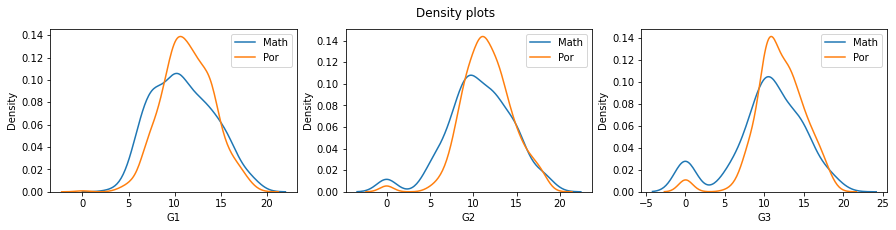

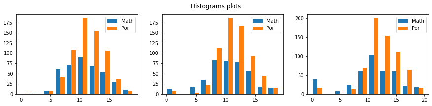

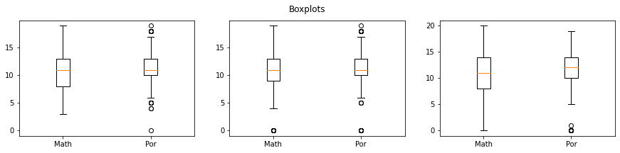

```python
dataMath = data.loc[data["Subject"] == 'Math']
dataPor = data.loc[data["Subject"] == 'Por']
width, height = 15, 3

# Density plots:
fig, (ax1, ax2, ax3) = plt.subplots(1, 3, figsize=(width, height))
fig.suptitle('Density plots')
sns.kdeplot(dataMath["G1"], ax=ax1)
sns.kdeplot(dataPor["G1"], ax=ax1)
sns.kdeplot(dataMath["G2"], ax=ax2)
sns.kdeplot(dataPor["G2"], ax=ax2)
sns.kdeplot(dataMath["G3"], ax=ax3)
sns.kdeplot(dataPor["G3"], ax=ax3)
ax1.legend(["Math", "Por"])
ax2.legend(["Math", "Por"])
ax3.legend(["Math", "Por"])
plt.show()
plt.close()

# Histograms plots
fig, (ax1, ax2, ax3) = plt.subplots(1, 3, figsize=(width, height))
fig.suptitle('Histograms plots')
ax1.hist([dataMath["G1"], dataPor["G1"]], label=['Port', 'Math'])
ax2.hist([dataMath["G2"], dataPor["G2"]], label=['Port', 'Math'])
ax3.hist([dataMath["G3"], dataPor["G3"]], label=['Port', 'Math'])
ax1.legend(["Math", "Por"])
ax2.legend(["Math", "Por"])
ax3.legend(["Math", "Por"])
plt.show()
plt.close()

# Boxplots:
fig, (ax1, ax2, ax3) = plt.subplots(1, 3, figsize=(width, height))
fig.suptitle('Boxplots')
ax1.boxplot([dataMath["G1"], dataPor["G1"]], labels=["Math", "Por"])
ax2.boxplot([dataMath["G2"], dataPor["G2"]], labels=["Math", "Por"])
ax3.boxplot([dataMath["G3"], dataPor["G3"]], labels=["Math", "Por"])
plt.show()
plt.close()
```

### Задание 6

Оцените попарные зависимости числовых признаков.  
Рассчитайте и провизуализируйте матрицу корреляций. Дайте содержательный комментарий.

```
               age  failures  absences        G1        G2        G3
age       1.000000  0.282364  0.153196 -0.124121 -0.119475 -0.125282
failures  0.282364  1.000000  0.099998 -0.374175 -0.377172 -0.383145
absences  0.153196  0.099998  1.000000 -0.092425 -0.089332 -0.045671
G1       -0.124121 -0.374175 -0.092425  1.000000  0.858739  0.809142
G2       -0.119475 -0.377172 -0.089332  0.858739  1.000000  0.910743
G3       -0.125282 -0.383145 -0.045671  0.809142  0.910743  1.000000
```

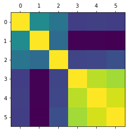

```python
# !! Interpretation of correlation coefficient values !!
# 1) up to 0.2 - Very weak
# 2) up to 0.5 - Weak
# 3) up to 0.7 - average
# 4) up to 0.9 - high
# 5) over 0.9 - very hign correlation


# Firstly, we need to Identify pure numeric attributes.
# I think, that ["age", "failures", "absences", "G1", "G2", "G3"] are numeric.
plt.figure(figsize=(15, 10))
corr_matrix = data[["age", "failures", "absences", "G1", "G2", "G3"]].corr()
print(corr_matrix)
plt.matshow(corr_matrix)
plt.show()
```

### Задание 7

Оцените попарные зависимости нечисловых (категориальных) признаков, дайте содержательный комментарий.

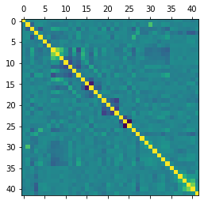

|  | ID | Subject | school | sex | address | famsize | Pstatus | Medu | Fedu | Mjob_teacher | Mjob_services | Mjob_other | Mjob_health | Mjob_at_home | Fjob_teacher | Fjob_services | Fjob_other | Fjob_health | Fjob_at_home | reason_reputation | reason_other | reason_home | reason_course | guardian_other | guardian_mother | guardian_father | traveltime | studytime | schoolsup | … |
| --- | --- | --- | --- | --- | --- | --- | --- | --- | --- | --- | --- | --- | --- | --- | --- | --- | --- | --- | --- | --- | --- | --- | --- | --- | --- | --- | --- | --- | --- | --- |
| ID | 1.000000 | -0.015238 | 0.002636 | 0.029218 | 0.030664 | 0.056316 | -0.025689 | 0.006227 | -0.009151 | 0.028801 | -0.030010 | -0.008871 | -0.008321 | 0.024805 | 0.042920 | -0.009063 | 0.010879 | -0.019640 | -0.033377 | -0.008557 | -0.014064 | 0.021048 | -0.002345 | 0.000327 | 0.020027 | -0.021969 | 0.015738 | 0.040464 | 0.018904 | … |
| Subject | -0.015238 | 1.000000 | -0.256088 | 0.062192 | 0.087916 | 0.007705 | -0.029497 | -0.101246 | -0.094795 | -0.052725 | -0.059108 | 0.040494 | -0.021842 | 0.073121 | -0.036023 | -0.002293 | 0.015745 | -0.025293 | 0.028896 | -0.051832 | 0.031532 | -0.052131 | 0.070995 | -0.033924 | 0.010492 | 0.009065 | 0.079881 | -0.060934 | 0.037141 | … |
| school | 0.002636 | -0.256088 | 1.000000 | -0.074955 | -0.341657 | -0.034882 | -0.024030 | 0.235114 | 0.187611 | 0.085061 | 0.110469 | -0.049607 | 0.067846 | -0.176482 | 0.080695 | -0.072556 | 0.057817 | 0.063836 | -0.118618 | 0.156975 | -0.185319 | 0.112408 | -0.119580 | 0.000164 | 0.050685 | -0.055202 | -0.258834 | 0.133255 | -0.130498 | … |
| sex | 0.029218 | 0.062192 | -0.074955 | 1.000000 | 0.011556 | -0.094361 | -0.051337 | -0.109387 | -0.070786 | -0.132241 | -0.038162 | 0.016424 | -0.017382 | 0.144979 | -0.046359 | -0.031428 | 0.009352 | 0.027762 | 0.064619 | 0.057261 | -0.026260 | -0.058480 | 0.017987 | 0.027853 | 0.024757 | -0.043723 | -0.042508 | 0.239972 | -0.119411 | … |
| address | 0.030664 | 0.087916 | -0.341657 | 0.011556 | 1.000000 | -0.054484 | 0.074097 | -0.179720 | -0.124303 | -0.061789 | -0.093365 | 0.040166 | -0.090991 | 0.166054 | -0.024419 | -0.017784 | 0.063121 | -0.068546 | -0.017515 | 0.031823 | 0.074252 | -0.161658 | 0.068215 | 0.009037 | 0.019957 | -0.027150 | 0.343803 | -0.037480 | 0.023583 | … |
| famsize | 0.056316 | 0.007705 | -0.034882 | -0.094361 | -0.054484 | 1.000000 | -0.207302 | -0.025556 | -0.047290 | 0.050327 | 0.029792 | -0.060404 | 0.007552 | -0.004664 | -0.078831 | -0.002748 | 0.016224 | 0.021480 | 0.034079 | 0.026257 | -0.039076 | 0.011608 | -0.008699 | -0.019775 | 0.021165 | -0.011075 | 0.031550 | -0.035109 | 0.045552 | … |
| Pstatus | -0.025689 | -0.029497 | -0.024030 | -0.051337 | 0.074097 | -0.207302 | 1.000000 | -0.077133 | -0.049156 | 0.027796 | -0.044868 | -0.029286 | 0.016727 | 0.049887 | -0.030545 | 0.092286 | -0.050112 | -0.019227 | -0.022969 | -0.022898 | 0.034559 | -0.035364 | 0.029409 | -0.088464 | -0.069200 | 0.128616 | 0.033883 | 0.005049 | 0.020789 | … |
| Medu | 0.006227 | -0.101246 | 0.235114 | -0.109387 | -0.179720 | -0.025556 | -0.077133 | 1.000000 | 0.642063 | 0.452952 | 0.104984 | -0.231026 | 0.258135 | -0.387814 | 0.260111 | -0.019372 | -0.115679 | 0.128323 | -0.091603 | 0.126800 | -0.022861 | 0.024313 | -0.116806 | -0.103730 | 0.097703 | -0.043620 | -0.238181 | 0.090616 | 0.023618 | … |
| Fedu | -0.009151 | -0.094795 | 0.187611 | -0.070786 | -0.124303 | -0.047290 | -0.049156 | 0.642063 | 1.000000 | 0.307594 | 0.079390 | -0.200426 | 0.133393 | -0.188731 | 0.348978 | 0.024698 | -0.230861 | 0.202267 | -0.084975 | 0.075322 | -0.025451 | 0.011945 | -0.059851 | -0.072834 | -0.046298 | 0.094286 | -0.196328 | 0.033458 | -0.032450 | … |
| Mjob_teacher | 0.028801 | -0.052725 | 0.085061 | -0.132241 | -0.061789 | 0.050327 | 0.027796 | 0.452952 | 0.307594 | 1.000000 | -0.205494 | -0.296623 | -0.110108 | -0.180173 | 0.238998 | 0.023525 | -0.138609 | 0.058167 | -0.045665 | -0.026457 | -0.032848 | 0.012601 | 0.032159 | -0.057904 | 0.134808 | -0.111614 | -0.083252 | 0.020386 | 0.071369 | … |
| Mjob_services | -0.030010 | -0.059108 | 0.110469 | -0.038162 | -0.093365 | 0.029792 | -0.044868 | 0.104984 | 0.079390 | -0.205494 | 1.000000 | -0.428556 | -0.159082 | -0.260311 | 0.010565 | 0.178554 | -0.154726 | -0.016268 | -0.011512 | 0.054781 | 0.009551 | -0.026761 | -0.029825 | -0.042122 | 0.031467 | -0.008790 | -0.068560 | 0.019401 | -0.048479 | … |
| Mjob_other | -0.008871 | 0.040494 | -0.049607 | 0.016424 | 0.040166 | -0.060404 | -0.029286 | -0.231026 | -0.200426 | -0.296623 | -0.428556 | 1.000000 | -0.229629 | -0.375749 | -0.088449 | -0.165118 | 0.253338 | -0.108277 | -0.039161 | 0.014907 | -0.060040 | 0.084072 | -0.049420 | 0.062615 | -0.103962 | 0.075237 | 0.038616 | -0.007451 | -0.040443 | … |
| Mjob_health | -0.008321 | -0.021842 | 0.067846 | -0.017382 | -0.090991 | 0.007552 | 0.016727 | 0.258135 | 0.133393 | -0.110108 | -0.159082 | -0.229629 | 1.000000 | -0.139480 | -0.031023 | 0.016382 | -0.056439 | 0.215922 | -0.058296 | 0.096387 | 0.052812 | -0.018691 | -0.099643 | -0.038167 | -0.040145 | 0.066676 | -0.106540 | -0.015221 | 0.059903 | … |
| Mjob_at_home | 0.024805 | 0.073121 | -0.176482 | 0.144979 | 0.166054 | -0.004664 | 0.049887 | -0.387814 | -0.188731 | -0.180173 | -0.260311 | -0.375749 | -0.139480 | 1.000000 | -0.082333 | -0.017889 | 0.007336 | -0.045879 | 0.140441 | -0.122002 | 0.056045 | -0.073890 | 0.135573 | 0.042825 | 0.009221 | -0.035868 | 0.170171 | -0.018424 | 0.000876 | … |
| Fjob_teacher | 0.042920 | -0.036023 | 0.080695 | -0.046359 | -0.024419 | -0.078831 | -0.030545 | 0.260111 | 0.348978 | 0.238998 | 0.010565 | -0.088449 | -0.031023 | -0.082333 | 1.000000 | -0.160564 | -0.290331 | -0.052096 | -0.064745 | -0.013419 | 0.042641 | -0.009771 | -0.006218 | -0.070651 | -0.002810 | 0.045690 | -0.021649 | -0.033607 | -0.069742 | … |
| Fjob_services | -0.009063 | -0.002293 | -0.072556 | -0.031428 | -0.017784 | -0.002748 | 0.092286 | -0.019372 | 0.024698 | 0.023525 | 0.178554 | -0.165118 | 0.016382 | -0.017889 | -0.160564 | 1.000000 | -0.702118 | -0.125986 | -0.156575 | -0.026897 | 0.075630 | -0.025533 | -0.001163 | -0.028599 | -0.086476 | 0.111271 | -0.031258 | 0.011951 | 0.048910 | … |
| Fjob_other | 0.010879 | 0.015745 | 0.057817 | 0.009352 | 0.063121 | 0.016224 | -0.050112 | -0.115679 | -0.230861 | -0.138609 | -0.154726 | 0.253338 | -0.056439 | 0.007336 | -0.290331 | -0.702118 | 1.000000 | -0.227808 | -0.283118 | 0.019367 | -0.097651 | 0.047763 | 0.001817 | 0.061771 | 0.112407 | -0.159480 | 0.099122 | -0.038541 | 0.027727 | … |
| Fjob_health | -0.019640 | -0.025293 | 0.063836 | 0.027762 | -0.068546 | 0.021480 | -0.019227 | 0.128323 | 0.202267 | 0.058167 | -0.016268 | -0.108277 | 0.215922 | -0.045879 | -0.052096 | -0.125986 | -0.227808 | 1.000000 | -0.050802 | 0.095716 | 0.060861 | -0.047241 | -0.079022 | -0.036099 | -0.049268 | 0.075346 | -0.090635 | 0.107722 | -0.082654 | … |
| Fjob_at_home | -0.033377 | 0.028896 | -0.118618 | 0.064619 | -0.017515 | 0.034079 | -0.022969 | -0.091603 | -0.084975 | -0.045665 | -0.011512 | -0.039161 | -0.058296 | 0.140441 | -0.064745 | -0.156575 | -0.283118 | -0.050802 | 1.000000 | -0.054547 | -0.032122 | -0.003024 | 0.069692 | 0.026456 | -0.028526 | 0.015047 | -0.052228 | 0.004087 | -0.011898 | … |
| reason_reputation | -0.008557 | -0.051832 | 0.156975 | 0.057261 | 0.031823 | 0.026257 | -0.022898 | 0.126800 | 0.075322 | -0.026457 | 0.054781 | 0.014907 | 0.096387 | -0.122002 | -0.013419 | -0.026897 | 0.019367 | 0.095716 | -0.054547 | 1.000000 | -0.189602 | -0.319792 | -0.467110 | -0.011835 | -0.019277 | 0.028099 | -0.063705 | 0.187202 | -0.026430 | … |
| reason_other | -0.014064 | 0.031532 | -0.185319 | -0.026260 | 0.074252 | -0.039076 | 0.034559 | -0.022861 | -0.025451 | -0.032848 | 0.009551 | -0.060040 | 0.052812 | 0.056045 | 0.042641 | 0.075630 | -0.097651 | 0.060861 | -0.032122 | -0.189602 | 1.000000 | -0.194613 | -0.284265 | -0.056138 | 0.018414 | 0.013859 | 0.040928 | -0.097277 | 0.003072 | … |
| reason_home | 0.021048 | -0.052131 | 0.112408 | -0.058480 | -0.161658 | 0.011608 | -0.035364 | 0.024313 | 0.011945 | 0.012601 | -0.026761 | 0.084072 | -0.018691 | -0.073890 | -0.009771 | -0.025533 | 0.047763 | -0.047241 | -0.003024 | -0.319792 | -0.194613 | 1.000000 | -0.479456 | 0.051896 | -0.023724 | -0.005527 | -0.112132 | -0.019542 | -0.032087 | … |
| reason_course | -0.002345 | 0.070995 | -0.119580 | 0.017987 | 0.068215 | -0.008699 | 0.029409 | -0.116806 | -0.059851 | 0.032159 | -0.029825 | -0.049420 | -0.099643 | 0.135573 | -0.006218 | -0.001163 | 0.001817 | -0.079022 | 0.069692 | -0.467110 | -0.284265 | -0.479456 | 1.000000 | -0.000512 | 0.026066 | -0.028029 | 0.128033 | -0.084553 | 0.049074 | … |
| guardian_other | 0.000327 | -0.033924 | 0.000164 | 0.027853 | 0.009037 | -0.019775 | -0.088464 | -0.103730 | -0.072834 | -0.057904 | -0.042122 | 0.062615 | -0.038167 | 0.042825 | -0.070651 | -0.028599 | 0.061771 | -0.036099 | 0.026456 | -0.011835 | -0.056138 | 0.051896 | -0.000512 | 1.000000 | -0.416173 | -0.151021 | 0.070983 | 0.018770 | 0.039250 | … |
| guardian_mother | 0.020027 | 0.010492 | 0.050685 | 0.024757 | 0.019957 | 0.021165 | -0.069200 | 0.097703 | -0.046298 | 0.134808 | 0.031467 | -0.103962 | -0.040145 | 0.009221 | -0.002810 | -0.086476 | 0.112407 | -0.049268 | -0.028526 | -0.019277 | 0.018414 | -0.023724 | 0.026066 | -0.416173 | 1.000000 | -0.836005 | -0.061961 | -0.020958 | 0.012996 | … |
| guardian_father | -0.021969 | 0.009065 | -0.055202 | -0.043723 | -0.027150 | -0.011075 | 0.128616 | -0.043620 | 0.094286 | -0.111614 | -0.008790 | 0.075237 | 0.066676 | -0.035868 | 0.045690 | 0.111271 | -0.159480 | 0.075346 | 0.015047 | 0.028099 | 0.013859 | -0.005527 | -0.028029 | -0.151021 | -0.836005 | 1.000000 | 0.024526 | 0.011457 | -0.037814 | … |
| traveltime | 0.015738 | 0.079881 | -0.258834 | -0.042508 | 0.343803 | 0.031550 | 0.033883 | -0.238181 | -0.196328 | -0.083252 | -0.068560 | 0.038616 | -0.106540 | 0.170171 | -0.021649 | -0.031258 | 0.099122 | -0.090635 | -0.052228 | -0.063705 | 0.040928 | -0.112132 | 0.128033 | 0.070983 | -0.061961 | 0.024526 | 1.000000 | -0.081328 | 0.033940 | … |
| studytime | 0.040464 | -0.060934 | 0.133255 | 0.239972 | -0.037480 | -0.035109 | 0.005049 | 0.090616 | 0.033458 | 0.020386 | 0.019401 | -0.007451 | -0.015221 | -0.018424 | -0.033607 | 0.011951 | -0.038541 | 0.107722 | 0.004087 | 0.187202 | -0.097277 | -0.019542 | -0.084553 | 0.018770 | -0.020958 | 0.011457 | -0.081328 | 1.000000 | -0.070598 | … |
| schoolsup | 0.018904 | 0.037141 | -0.130498 | -0.119411 | 0.023583 | 0.045552 | 0.020789 | 0.023618 | -0.032450 | 0.071369 | -0.048479 | -0.040443 | 0.059903 | 0.000876 | -0.069742 | 0.048910 | 0.027727 | -0.082654 | -0.011898 | -0.026430 | 0.003072 | -0.032087 | 0.049074 | 0.039250 | 0.012996 | -0.037814 | 0.033940 | -0.070598 | 1.000000 | … |
| famsup | -0.024350 | -0.000590 | -0.088460 | -0.137696 | 0.011975 | 0.067340 | -0.013370 | -0.143063 | -0.153342 | -0.043520 | -0.063128 | 0.103599 | -0.063831 | 0.019856 | -0.041942 | 0.030687 | 0.047566 | -0.089764 | -0.041541 | -0.073795 | 0.085285 | -0.017504 | 0.026378 | -0.032767 | 0.026898 | -0.009468 | 0.026117 | -0.143858 | 0.086945 | … |
| paid | -0.018090 | 0.473453 | -0.130125 | -0.002179 | 0.053024 | 0.028290 | -0.040341 | -0.161349 | -0.118897 | -0.089668 | -0.048277 | 0.082558 | -0.049940 | 0.059666 | 0.026219 | -0.002446 | -0.004423 | -0.040630 | 0.020522 | -0.026156 | -0.024998 | -0.085119 | 0.112683 | -0.024101 | -0.038803 | 0.056728 | 0.083679 | -0.105704 | 0.021606 | … |
| activities | 0.015968 | 0.022794 | -0.097932 | 0.116368 | -0.022095 | 0.009434 | -0.100576 | -0.116924 | -0.093800 | -0.102977 | -0.054143 | 0.083612 | -0.010477 | 0.048689 | -0.014855 | -0.049846 | 0.060369 | 0.002608 | -0.019100 | -0.141467 | 0.065295 | 0.068921 | 0.021521 | 0.030655 | -0.034128 | 0.018603 | 0.025834 | -0.078847 | 0.001109 | … |
| nursery | -0.027300 | -0.009498 | -0.019349 | -0.030492 | 0.031946 | -0.101279 | 0.054016 | -0.149287 | -0.104681 | -0.087181 | -0.027609 | 0.089281 | -0.048189 | 0.025619 | -0.010030 | 0.008235 | 0.043820 | -0.051856 | -0.054813 | -0.048640 | 0.002981 | 0.007495 | 0.033645 | 0.125651 | -0.087220 | 0.018996 | 0.018641 | -0.056817 | 0.028795 | … |
| higher | 0.002395 | 0.096707 | -0.131382 | -0.078775 | 0.074716 | -0.000650 | -0.007339 | -0.206551 | -0.191956 | -0.094354 | -0.035714 | 0.021075 | -0.089128 | 0.153985 | -0.050270 | 0.008462 | 0.001482 | -0.044062 | 0.068422 | -0.097860 | 0.076511 | -0.055619 | 0.086021 | 0.131501 | -0.052720 | -0.022041 | 0.081857 | -0.186556 | 0.077115 | … |
| internet | -0.026461 | 0.078377 | -0.222993 | 0.062671 | 0.194790 | -0.008315 | -0.065260 | -0.249728 | -0.170012 | -0.143140 | -0.127412 | 0.063474 | -0.088132 | 0.240790 | 0.004782 | -0.066757 | 0.021934 | 0.005809 | 0.071043 | -0.086240 | 0.043032 | -0.063627 | 0.103707 | -0.001605 | 0.024057 | -0.025185 | 0.169485 | -0.049695 | -0.016827 | … |
| romantic | -0.010553 | -0.032993 | 0.075740 | -0.107257 | -0.022449 | 0.006371 | 0.044521 | 0.007615 | 0.037402 | 0.048961 | 0.055779 | -0.039529 | -0.021874 | -0.037300 | -0.024561 | 0.002171 | 0.020059 | 0.015780 | -0.034118 | 0.051254 | -0.050789 | -0.011900 | -0.002463 | -0.126645 | 0.026186 | 0.047958 | -0.012305 | -0.035986 | -0.089316 | … |
| famrel | 0.040288 | -0.003715 | 0.033218 | -0.066251 | 0.015551 | -0.012913 | 0.042315 | 0.014486 | 0.010725 | -0.007888 | 0.032746 | 0.008550 | -0.038285 | -0.012876 | -0.056384 | 0.046341 | 0.015540 | 0.005205 | -0.067282 | 0.012193 | 0.002907 | -0.017184 | 0.002718 | -0.022894 | 0.006697 | 0.006535 | -0.010183 | 0.009534 | 0.017245 | … |
| freetime | 0.029062 | -0.025949 | -0.026008 | -0.181603 | 0.009744 | -0.007249 | 0.038714 | 0.001054 | 0.002142 | 0.072738 | 0.017525 | -0.017702 | -0.015520 | -0.047825 | 0.003558 | -0.051199 | 0.038416 | -0.039445 | 0.045318 | -0.023762 | -0.008310 | -0.064393 | 0.082123 | 0.048511 | 0.003161 | -0.032711 | -0.007403 | -0.094429 | 0.026126 | … |
| goout | -0.046185 | 0.032011 | -0.037000 | -0.062530 | -0.030790 | 0.005889 | 0.020498 | 0.025614 | 0.030075 | -0.043558 | 0.031040 | 0.006338 | 0.046969 | -0.036958 | -0.031480 | -0.021470 | 0.043242 | 0.006843 | -0.023500 | -0.018991 | -0.002354 | -0.012108 | 0.028489 | 0.005225 | 0.056714 | -0.064810 | 0.049740 | -0.072941 | 0.051227 | … |
| Dalc | -0.028966 | 0.014030 | -0.067255 | -0.273531 | 0.065319 | 0.077001 | 0.015016 | -0.001096 | -0.000379 | 0.025456 | 0.045862 | -0.003120 | -0.075688 | -0.014899 | -0.013059 | 0.098913 | -0.062511 | -0.017240 | -0.029019 | -0.101511 | 0.134013 | 0.041371 | -0.031405 | 0.082680 | -0.078755 | 0.035723 | 0.110928 | -0.159742 | 0.025098 | … |
| Walc | -0.079436 | -0.004449 | -0.029132 | -0.305886 | 0.046034 | 0.089432 | 0.048182 | -0.032166 | 0.016997 | 0.010737 | 0.027243 | -0.046271 | 0.025291 | 0.001770 | -0.089671 | 0.097164 | 0.009320 | -0.039949 | -0.079597 | -0.049178 | 0.073049 | 0.013950 | -0.014902 | -0.018522 | -0.003109 | 0.014557 | 0.086288 | -0.227851 | 0.096399 | … |
| health | -0.014859 | -0.006205 | 0.053214 | -0.141113 | 0.010895 | -0.009147 | 0.016213 | -0.013254 | 0.034288 | 0.017106 | 0.075564 | -0.034189 | 0.036168 | -0.078445 | 0.018647 | -0.062321 | 0.029574 | 0.089110 | -0.036065 | -0.124371 | 0.007388 | -0.015782 | 0.116804 | -0.012256 | -0.003484 | 0.011183 | -0.029002 | -0.063044 | -0.000785 | … |

```python
# Slice numeric data, create pure catigorical Data frame
plt.figure(figsize=(15, 10))
catigoricalDf = numericDf.drop(columns=["age", "failures", "absences", "G1", "G2", "G3"])
corr_matrix = catigoricalDf.corr()
plt.matshow(corr_matrix)
plt.show()
corr_matrix
```

## CONCLUSION

- Overall, the relationship between categorical features is weak. Despite this, there are some interesting relationships.
- For exapmle, there is an avarage correlation coefficient (0.64) between "Medu" and "Fedu". Obviously, the level of education people also take into account when choosing a partner.
- Also there are almost avarage correlation (0.45) between "Medu" and "Mjob_teacher", this may indicate that educated women are more likely to become teachers.
- The correlation between "Walc" and "Dalc" shows an interesting value - (0.64). Thus, we can guess that people, who drink on a weekday can also drink on the weekends and vice versa.
- Needless to say, that there are some black cells - correlations between atrributes, created by one-hot encoding from one column. I think these are incorrect connections that do not need to be considered.

### Задание 8

- Оцените, есть ли разница в употреблении алкоголя между парнями и девушками. Кто пьет больше?
- Оцените связь употребления алкоголя с признаками: address, Pstatus, higher, romantic, freetime.
- Оцените связь употребления алкоголя с уровнем образования опекуна (для случаев, где это известно).
- Сравните употребление алкоголя для 50 лучших учеников и 50 худших (по `G3`). Выполните сравнение отдельно для каждого предмета (`Math` и `Por`). Дайте содержательный комментарий.

**Tip:** для выполнения задания пригодятся боксплоты и гистограммы.

### Task 1:

```
Men alco info:   	Average Dalc: 1.7770419426048565 	Average Walc: 2.728476821192053
Women alco info: 	Average Dalc: 1.2741116751269035 	Average Walc: 1.9340101522842639
Overall:
Men alco stats: 2.252759381898455
Women alco stats: 1.6040609137055837
```

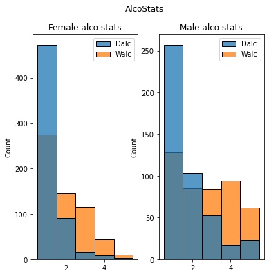

```python
# Task 1
men = data.loc[data["sex"] == 'M']
women = data.loc[data["sex"] == 'F']
men_Dalc_mean = men['Dalc'].describe()["mean"]
men_Walc_mean = men['Walc'].describe()["mean"]
women_Dalc_mean = women['Dalc'].describe()["mean"]
women_Walc_mean = women['Walc'].describe()["mean"]
print(f"Men alco info:   \tAverage Dalc: {men_Dalc_mean} \tAverage Walc: {men_Walc_mean}")
print(f"Women alco info: \tAverage Dalc: {women_Dalc_mean} \tAverage Walc: {women_Walc_mean}")
print("Overall: ")
print(f"Men alco stats: {(men_Dalc_mean + men_Walc_mean) / 2}")
print(f"Women alco stats: {(women_Dalc_mean + women_Walc_mean) / 2}")
alco_stats = data[["sex", "Dalc", "Walc"]]
fig, (ax1, ax2) = plt.subplots(1, 2, figsize=(6, 6))
fig.suptitle('AlcoStats')
sns.histplot(alco_stats.loc[alco_stats["sex"] == "F"], discrete=True, ax=ax1)
ax1.set_title('Female alco stats')
sns.histplot(alco_stats.loc[alco_stats["sex"] == "M"], discrete=True, ax=ax2)
ax2.set_title('Male alco stats')
plt.show()
plt.close()
```

## Small conclusion

According to statistics, men drink more than women on both weekdays and weekends  
On average, men drink **40% more** than women

### Task 2:

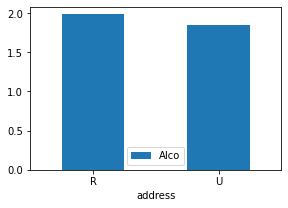

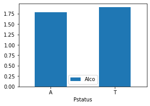

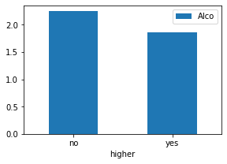

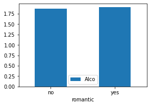

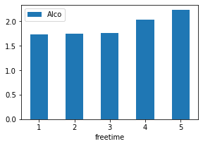

```python
# Task2
# Firstly, I want to summarize "Dalc" and "Walc"
cols = ["Walc", "Dalc"]
data_temp = data.eval("Alco = ({}) / 2".format("+".join(cols))).drop(columns=cols)
for attr in ("address", "Pstatus", "higher", "romantic", "freetime"):
    data_temp_ = data_temp[["Alco", attr]]
    data_mean = data_temp_.groupby([attr]).mean()
    data_mean.plot.bar(rot=0, subplots=False,figsize=(4.5, 3))
```

## Small Conclusion

Honestly, results show us image of real life  
Сategories of people who drink more alcohol:

- people living outside the city ("address" = R)
- people whose parents live together ("Pstatus" = T)
- people who do not want to obtain higher education ("higher" = no)
- people who are in a romantic relationship (have someone to drink with)
- people who have a lot of free time

### Task 3:

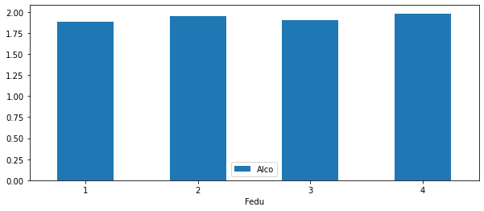

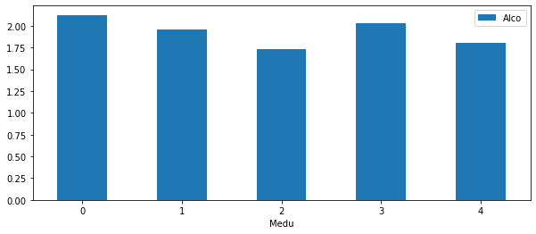

```python
# Firstly, we need to find entries with value of "guardian" attribute != "other"
data_temp1 = data_temp.loc[data["guardian"] != "other"]
data_temp1 = data_temp1[["Medu", "Fedu", "Alco", "guardian"]]
father_data = data_temp1.loc[data_temp1["guardian"] == "father"].drop(columns="Medu")
mother_data = data_temp1.loc[data_temp1["guardian"] == "mother"].drop(columns="Fedu")
for data_set in (father_data, mother_data):
    attr = data_set.columns.tolist()[0]
    data_mean = data_set.groupby([attr]).mean()
    data_mean.plot.bar(rot=0, subplots=False,figsize=(10, 4))
```

## Small conclusion

As you can see on bar charts, there are some interesting result:

- As for cases when guardian is father, education has almost no effect on the level of alcohol consumption.
- However, as for guardian mother, with an increase in the level of education, alcohol consumption decreases, although with secondary education there is a strange jump in the amount of alcohol consumption

### Task 4:

```python
data_temp_ = data_temp.sort_values(by=["G3"])
data_temp1 = data_temp_[:50]
math_students_worst = data_temp1.loc[data_temp1["Subject"] == "Math"]
por_students_worst = data_temp1.loc[data_temp1["Subject"] == "Por"]
data_temp2 = data_temp_[-50:]
math_students_best = data_temp2.loc[data_temp2["Subject"] == "Math"]
por_students_best = data_temp2.loc[data_temp2["Subject"] == "Por"]
mean_alco_math_best_st = math_students_best["Alco"].mean()
mean_alco_por_best_st = por_students_best["Alco"].mean()
mean_alco_math_worst_st = math_students_worst["Alco"].mean()
mean_alco_por_worst_st = por_students_worst["Alco"].mean()
print("Statistics of top 50 best students in alcohol consumption: ")
print(f"Math students {mean_alco_math_best_st} VS {mean_alco_por_best_st} Por students")
print("Statistics of top 50 worst students in alcohol consumption: ")
print(f"Math students {mean_alco_math_worst_st} VS {mean_alco_por_worst_st} Por students")
```

```
Statistics of top 50 best students in alcohol consumption:
Math students 1.35 VS 1.4666666666666666 Por students
Statistics of top 50 worst students in alcohol consumption:
Math students 1.6527777777777777 VS 2.25 Por students
```

## Conclusion

- The top Portuguese students drink on average more than the students who attend math (by about 8 percent).
- It is surprising that even the worst math students drink less students of the Portuguese language. There is already a more significant difference, about 36 percent
- From this we can conclude that either students of the Portuguese language have a large amount of free time, or study is very difficult for them, which forces them to drink to relax

### Задание 9

Оцените зависимость итоговой оценки от следующих признаков:

- Пола
- Времени в пути от дома до школы
- Наличия дополнительной помощи в учебе (от членов семьи или вообще)
- Посещения платных дополнительных занятий
- Наличия интернета
- Наличия романтических отношений
- Употребления алкоголя

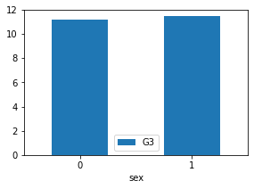

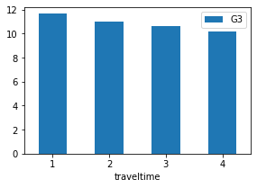

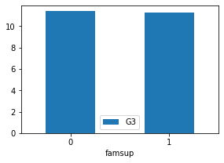

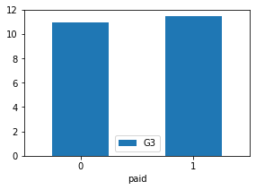

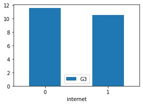

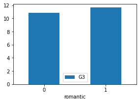

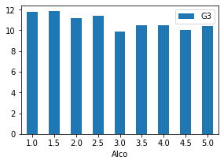

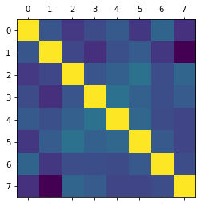

|  | G3 | sex | traveltime | famsup | paid | internet | romantic | Alco |
| --- | --- | --- | --- | --- | --- | --- | --- | --- |
| G3 | 1.000000 | 0.031472 | -0.102627 | -0.013313 | 0.049388 | -0.107064 | 0.100837 | -0.134547 |
| sex | 0.031472 | 1.000000 | -0.042508 | -0.137696 | -0.002179 | 0.062671 | -0.107257 | -0.323277 |
| traveltime | -0.102627 | -0.042508 | 1.000000 | 0.026117 | 0.083679 | 0.169485 | -0.012305 | 0.106664 |
| famsup | -0.013313 | -0.137696 | 0.026117 | 1.000000 | 0.169424 | 0.082522 | -0.007482 | 0.058816 |
| paid | 0.049388 | -0.002179 | 0.083679 | 0.169424 | 1.000000 | 0.114189 | -0.019490 | -0.045301 |
| internet | -0.107064 | 0.062671 | 0.169485 | 0.082522 | 0.114189 | 1.000000 | 0.048887 | -0.045481 |
| romantic | 0.100837 | -0.107257 | -0.012305 | -0.007482 | -0.019490 | 0.048887 | 1.000000 | -0.012789 |
| Alco | -0.134547 | -0.323277 | 0.106664 | 0.058816 | -0.045301 | -0.045481 | -0.012789 | 1.000000 |

```python
# Firstly, I want to extract these columns in separate data set
cols = ["Walc", "Dalc"]

if cols[0] in numericDf.columns.tolist():
    numericDf = numericDf.eval("Alco = ({}) / 2".format("+".join(cols))).drop(columns=cols)
dataTemp = numericDf[["G3", "sex", "traveltime", "famsup", "paid", "internet", "romantic", "Alco"]]
for attr in ("sex", "traveltime", "famsup", "paid", "internet", "romantic", "Alco"):
    data_temp_ = dataTemp[["G3", attr]]
    data_mean = data_temp_.groupby([attr]).mean()
    data_mean.plot.bar(rot=0, subplots=False,figsize=(4.5, 3))
corr_matrix = dataTemp.corr()
plt.matshow(corr_matrix)
plt.show()
corr_matrix
```

## Conclusion

- According to bar charts, i can say with confidence, that "sex", "famsup", "paid" attributes have very little effect on the value of the final score ("G3")
- The effect of "traveltime is inversely proportional. As the commuting time increases, the final grade drops. This is quite reasonable, because in this case, students are more often late and may miss some of the material.
- The presence of the Internet has a positive effect on the final score ("G3"). This is obvious, because the Internet gives almost unlimited access to knowledge.
- The presence of a romantic relationship, on the contrary, negatively affects the final score ("G3"). It is quite possible that for people in love, learning takes a back seat
- As for "Alco" bar chart, there are some fluctuations, however, the main behaviour is a downward trend. It means, that people, who drink a lot have more bad grades.
- Correlation coefficient graph and table does not display these dependencies as well, but some attribute pairs have a similar dependency.

### Задание 10

Добавьте в данные новый признак - итоговая оценка по 4-х балльной шкале:

- Отлично: 18 <= `G3` <= 20
- Хорошо: 14 <= `G3` <= 17
- Удовлетворительно: 8 <= `G3` <= 13
- Неудовлетворительно: `G3` < 8

Оцените распределение нового признака в зависимости от признака `reason` (причина выбора школы). Дайте содержательный комментарий.

```python
newDf = data.copy()
marks = {"Excellent": 4,
         "Good": 3,
         "Satisfactory": 2,
         "Unsatisfactory": 1}

new_column = list()
for g_3 in newDf["G3"]:
    if 18 <= g_3 <= 20:
        new_column.append(marks["Excellent"])
    elif 14 <= g_3 <= 17:
        new_column.append(marks["Good"])
    elif 8 <= g_3 <= 13:
        new_column.append(marks["Satisfactory"])
    elif g_3 < 8:
        new_column.append(marks["Unsatisfactory"])

newDf["marks"] = new_column
newDf
```

|  | ID | Subject | school | sex | age | address | famsize | Pstatus | Medu | Fedu | Mjob | Fjob | reason | guardian | traveltime | studytime | failures | schoolsup | famsup | paid | activities | nursery | higher | internet | romantic | famrel | freetime | goout | Dalc | … |
| --- | --- | --- | --- | --- | --- | --- | --- | --- | --- | --- | --- | --- | --- | --- | --- | --- | --- | --- | --- | --- | --- | --- | --- | --- | --- | --- | --- | --- | --- | --- |
| 0 | 100097 | Por | GP | F | 16 | U | GT3 | A | 3 | 4 | services | other | course | father | 1 | 1 | 0 | no | no | no | no | yes | yes | yes | no | 3 | 2 | 1 | 1 | … |
| 1 | 101021 | Por | GP | F | 17 | U | GT3 | T | 3 | 2 | other | other | course | mother | 1 | 2 | 0 | no | no | no | yes | no | yes | yes | no | 5 | 3 | 4 | 1 | … |
| 2 | 102965 | Por | GP | M | 16 | U | LE3 | T | 1 | 2 | health | services | course | mother | 2 | 1 | 2 | no | no | no | no | no | yes | yes | no | 4 | 4 | 5 | 3 | … |
| 3 | 102989 | Por | MS | M | 17 | U | GT3 | T | 2 | 3 | other | services | home | father | 2 | 2 | 0 | no | no | no | yes | yes | yes | yes | no | 4 | 4 | 3 | 1 | … |
| 4 | 103131 | Por | GP | F | 16 | U | GT3 | T | 1 | 1 | at_home | other | home | mother | 2 | 1 | 0 | no | yes | no | no | yes | yes | no | no | 4 | 3 | 2 | 1 | … |
| ... | ... | ... | ... | ... | ... | ... | ... | ... | ... | ... | ... | ... | ... | ... | ... | ... | ... | ... | ... | ... | ... | ... | ... | ... | ... | ... | ... | ... | ... | … |
| 1039 | 997832 | Math | GP | F | 15 | R | GT3 | T | 3 | 3 | services | services | reputation | other | 2 | 3 | 2 | no | yes | yes | yes | yes | yes | yes | yes | 4 | 2 | 1 | 2 | … |
| 1040 | 997897 | Por | GP | M | 15 | R | GT3 | T | 2 | 1 | health | services | reputation | mother | 1 | 2 | 0 | no | no | no | yes | yes | yes | yes | yes | 5 | 4 | 2 | 1 | … |
| 1041 | 998425 | Por | MS | F | 16 | R | LE3 | T | 1 | 1 | at_home | other | course | father | 3 | 2 | 0 | no | yes | no | no | yes | yes | no | no | 5 | 3 | 2 | 1 | … |
| 1042 | 999143 | Por | GP | M | 16 | U | GT3 | T | 2 | 1 | at_home | other | course | mother | 4 | 1 | 0 | no | no | no | no | yes | yes | no | no | 3 | 2 | 1 | 1 | … |
| 1043 | 999194 | Por | GP | M | 17 | R | GT3 | T | 1 | 3 | other | other | course | father | 3 | 2 | 1 | no | yes | no | yes | yes | yes | yes | no | 5 | 2 | 4 | 1 | … |

1044 rows × 36 columns

| reason | marks |
| --- | --- |
| course | 2.160465 |
| home | 2.209302 |
| other | 2.120370 |
| reputation | 2.375000 |

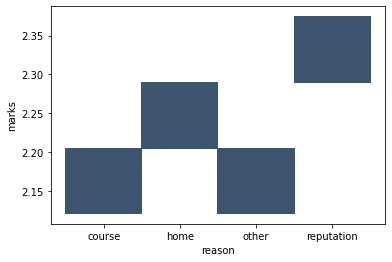

```python
temp = newDf[["marks", "reason"]]
temp = temp.groupby("reason").mean()
sns.histplot(data=temp, x="reason", y="marks")
temp
```

## Conclusion

- The average new score was in the range of 2 to 3 (from "Satisfactory" to "Good") for each reason.
- The highest average score is in the reputation category. This suggests that in schools with a good reputation, children learn better than in schools chosen for other reasons
- Lowest average score in the "other" category
- The average score in the "home" category is higher than in the "course" category. This may sound strange, but it seems that children whose schools are nearby are learning better

### Задание 11

Часть из представленных в данных студентов посещали оба курса - `Math` и `Por`.

- Предложите способ идентификации студентов и определите тех, кто посещал оба курса. Сколько таких студентов?
- Для этих студентов сравните оценки по двум предметам, дайте комментарий.

**Note:** Столбец `ID` является уникальным идентификатором наблюдения, но не студента. Он будет уникален для каждой строки.

```python
# To find a student who has attended both courses I propose to identify the records with the same values of personal attributes.
# In my opinion, personal attributes are considered to be:
personal_atrributes = ['school', 'sex', 'age', 'address', 'school', 'reason', 'traveltime',
'famsize', 'Pstatus', 'Medu', 'Fedu', 'Mjob', 'Fjob', 'reason', 'guardian', 'nursery', 'higher',
'internet', 'romantic', 'famrel', 'goout', 'Dalc', 'Walc', 'health']

student_duplicates = data[data.duplicated(personal_atrributes, keep='first')]
print("number of students attending both courses: ", len(student_duplicates))
print("Math mean: ", student_duplicates.loc[student_duplicates["Subject"] == "Math"]["G3"].mean())
print("Por mean: ", student_duplicates.loc[student_duplicates["Subject"] == "Por"]["G3"].mean())
```

```
number of students attending both courses:  360
Math mean:  10.329545454545455
Por mean:  12.282608695652174
```

## Conclusion

- I believe that students who attend both subjects can be identified by adding another column to our data, for example "FIO" column
- As we can see, the average score of such students in Portuguese is higher than in mathematics. This may be due to the fact that people devote more time to the Portuguese language, or they are simply humanitarians by nature.

### Задание 12

Предложите простую модель для определения (предсказания) итоговой оценки студента по 4-х балльной системе. Оцените точность предложенной модели.

```python
from sklearn.ensemble import RandomForestClassifier
from sklearn.model_selection import train_test_split
from sklearn.preprocessing import StandardScaler
from sklearn.metrics import confusion_matrix, classification_report
from sklearn.tree import DecisionTreeClassifier


data_temp = numericDf.copy()
data_temp["marks"] = newDf["marks"]

columns_to_drop = ["marks", "G1", "G2", "G3"]

X = data_temp.drop(columns_to_drop, axis=1)
y = data_temp["marks"]

X_train, X_test, y_train, y_test = train_test_split(X, y, test_size=0.2)

# Scale
sc = StandardScaler()
X_train = sc.fit_transform(X_train)
X_test = sc.transform(X_test)

# RFC
rfc = RandomForestClassifier(n_estimators=10)
rfc.fit(X_train, y_train)
pred_rfc = rfc.predict(X_test)

print(classification_report(y_test, pred_rfc))
print(confusion_matrix(y_test, pred_rfc))
```

```
              precision    recall  f1-score   support

           1       0.42      0.38      0.40        13
           2       0.73      0.87      0.79       135
           3       0.62      0.40      0.49        52
           4       0.00      0.00      0.00         9

    accuracy                           0.68       209
   macro avg       0.44      0.41      0.42       209
weighted avg       0.65      0.68      0.66       209

[[  5   8   0   0]
 [  6 117  11   1]
 [  1  29  21   1]
 [  0   7   2   0]]
```

```python
columns_to_drop = ["marks", "G1", "G2", "G3"]

X = data_temp.drop(columns_to_drop, axis=1)
y = data_temp["marks"]

X_train, X_test, y_train, y_test = train_test_split(X, y, test_size=0.2)

# Scale
sc = StandardScaler()
X_train = sc.fit_transform(X_train)
X_test = sc.transform(X_test)

# Decision Tree
dec = DecisionTreeClassifier(random_state=4)
dec.fit(X_train, y_train)
pred_dec = dec.predict(X_test)

print(classification_report(y_test, pred_rfc))
print(confusion_matrix(y_test, pred_rfc))
```

[output not shown]

```
              precision    recall  f1-score   support

           1       0.08      0.07      0.07        15
           2       0.65      0.78      0.71       130
           3       0.33      0.22      0.26        59
           4       0.00      0.00      0.00         5

    accuracy                           0.56       209
   macro avg       0.27      0.27      0.26       209
weighted avg       0.50      0.56      0.52       209

[[  1  10   4   0]
 [  6 102  21   1]
 [  5  41  13   0]
 [  0   3   2   0]]
```

## Conclusion

### Задание * (бонусное)

Дополнительное исследование данных и выводы положительно скажутся на оценке.

```python
# your code here
```